# Creating graphics with ggplot

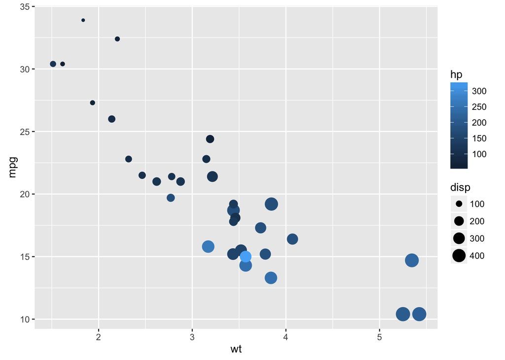

```r
ggplot(data = mtcars, aes(x = wt, y = mpg)) +
    geom_point(aes(colour = hp, size = disp))
```

Mapping factors gives us discrete scales instead of continuous

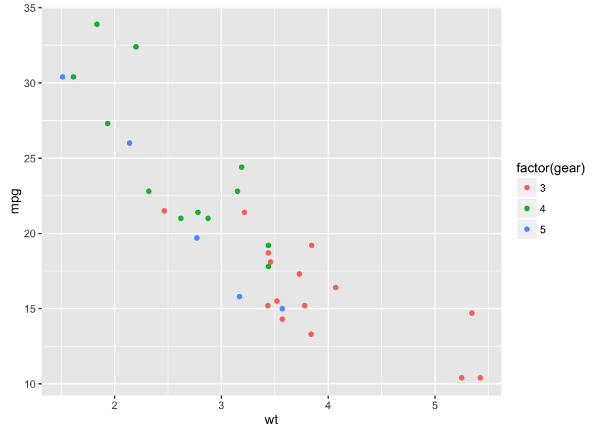

```r
ggplot(data = mtcars, aes(x = wt, y = mpg)) +
    geom_point(aes(colour = factor(gear)))
```

Ok, now we have a figure that we like, let’s put on some finishing touches

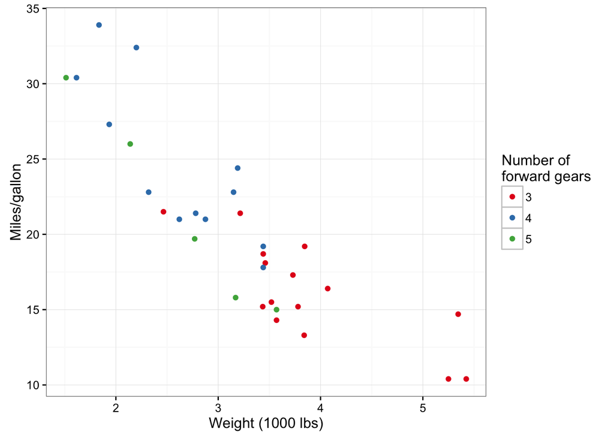

```r
ggplot(mtcars, aes(x = wt, y = mpg)) +
    geom_point(aes(colour = factor(gear))) +
    theme_bw() +
    scale_colour_brewer("Number of\nforward gears", palette = "Set1") +
    labs(x = "Weight (1000 lbs)", y = "Miles/gallon")
```

## A few more plot examples

### Boxplot

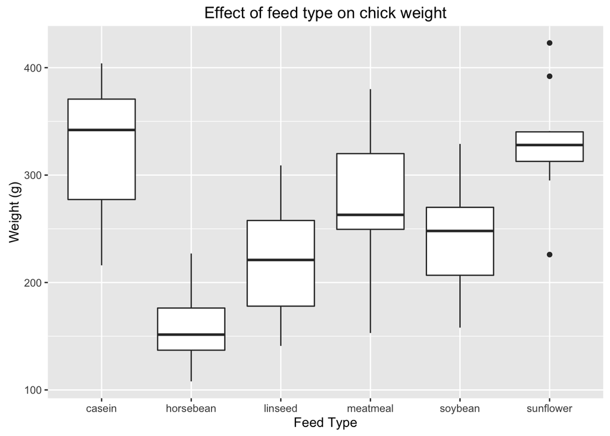

```r
ggplot(chickwts, aes(x = feed, y = weight)) +
    geom_boxplot() +
    labs(x = "Feed Type", y = "Weight (g)", title = "Effect of feed type on chick weight")
```

### Histogram

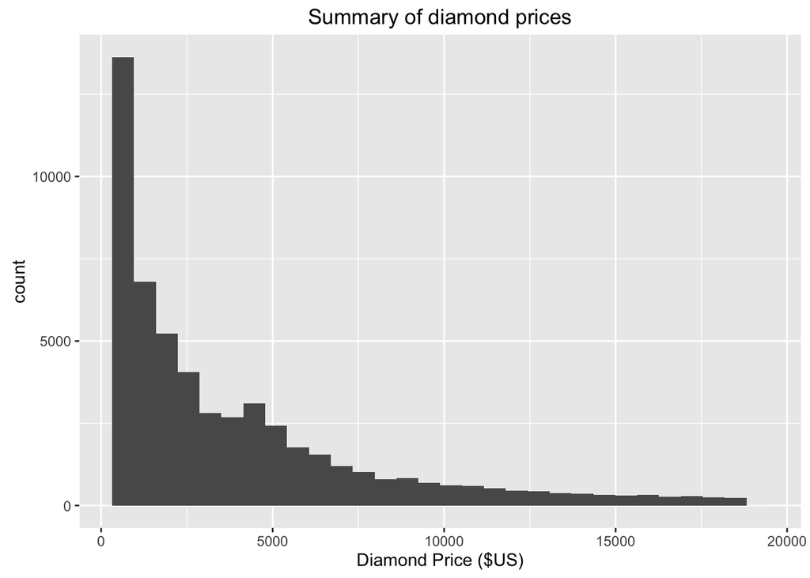

```r
ggplot(diamonds, aes(x = price)) +
    geom_histogram() +
    labs(x = "Diamond Price ($US)", title = "Summary of diamond prices")
## `stat_bin()` using `bins = 30`. Pick better value with `binwidth`.
```

### Line plot

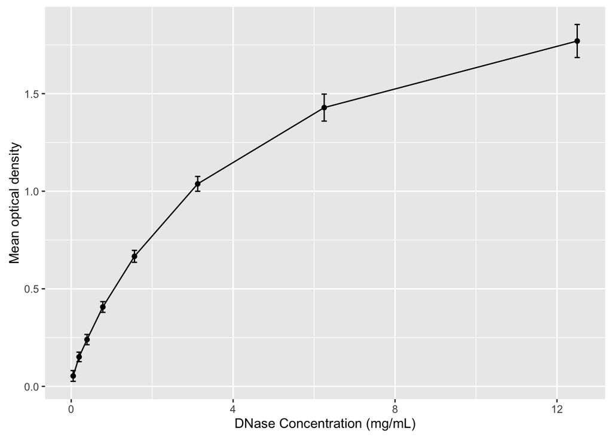

```r
DNase %>% group_by(conc) %>% summarise(mean = mean(density), sd = sd(density)) %>%
    ggplot(aes(x = conc, y = mean)) +
    geom_errorbar(aes(ymax = mean + sd, ymin = mean - sd)) +
    geom_point() + geom_line() +
    labs(x = "DNase Concentration (mg/mL)", y = "Mean optical density")
```

## Details

Aesthetics can be defined for each geom individually or for all geoms in the `ggplot()` call.

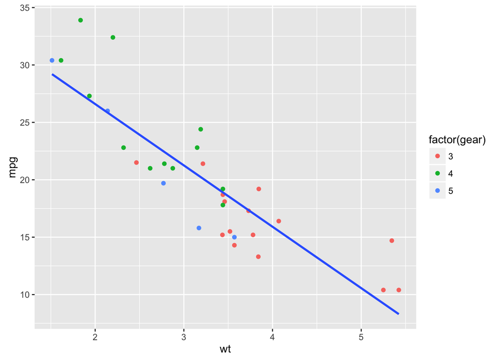

```r
ggplot(data = mtcars, aes(x = wt, y = mpg)) +
    geom_point(aes(colour = factor(gear))) +
    geom_smooth(method = "lm", se = FALSE)
```

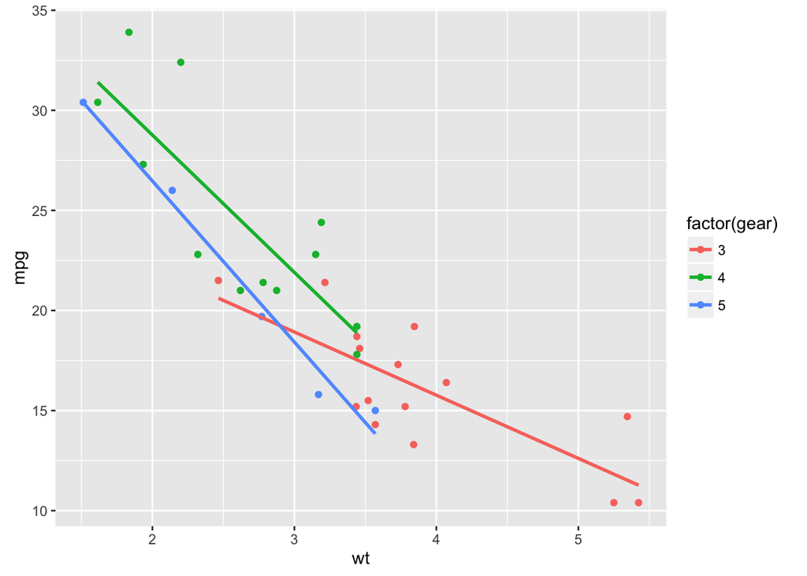

```r
ggplot(data = mtcars, aes(x = wt, y = mpg, colour = factor(gear))) +
    geom_point() + geom_smooth(method = "lm", se = FALSE)
```

We use facets to split our data into small multiples

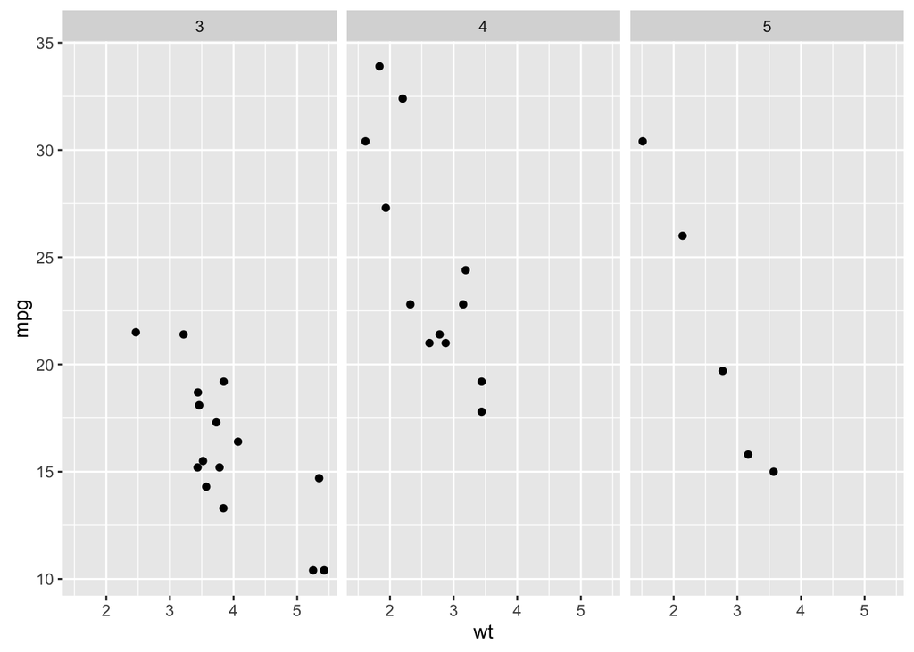

```r
ggplot(data = mtcars, aes(x = wt, y = mpg)) +
    geom_point() +
    facet_wrap(~gear)
```

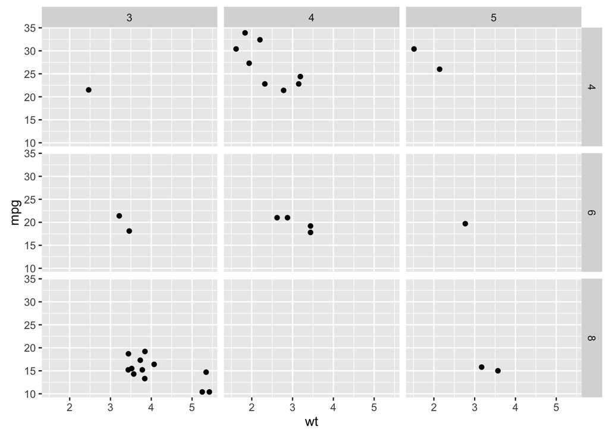

```r
ggplot(data = mtcars, aes(x = wt, y = mpg)) +
    geom_point() +
    facet_grid(cyl ~ gear)
```

## Exploring our data graphically

We’ll use the pa phenotype dataset here and tidy it up a bit

```r
pa = read_csv("../datasets/pa_phenotype_data.csv")
pa_tidy = pa %>% select(-X1) %>%
    gather(Phenotype, Measurement, -Strain_ID, -Event_num, -Clinical_Status,
                 -Date_of_Isolation, -Morphotype, -Mucoid)
```

For the growth rate in LB lets look at the change over time and see if there are differences between clinical states

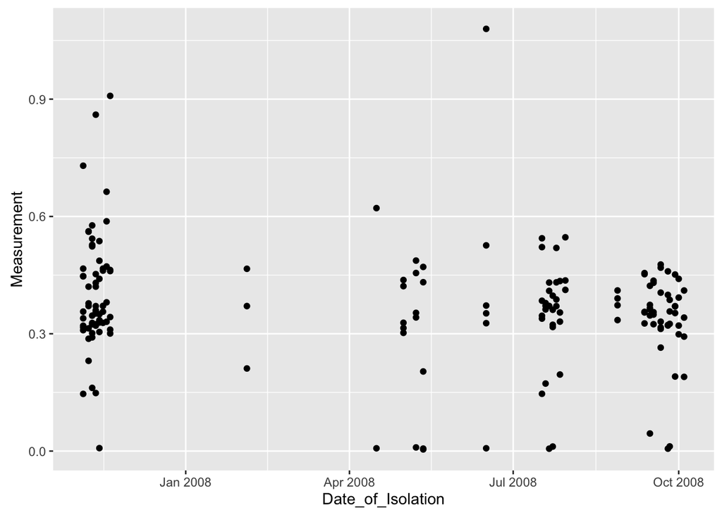

```r
pa_tidy %>% filter(Phenotype == "LB") %>%
    ggplot(aes(x = Date_of_Isolation, y = Measurement)) +
    geom_point()
```

Here we can see that the isolates are collected in bursts over short periods of time. Presumably these correspond to the excacerbation events.

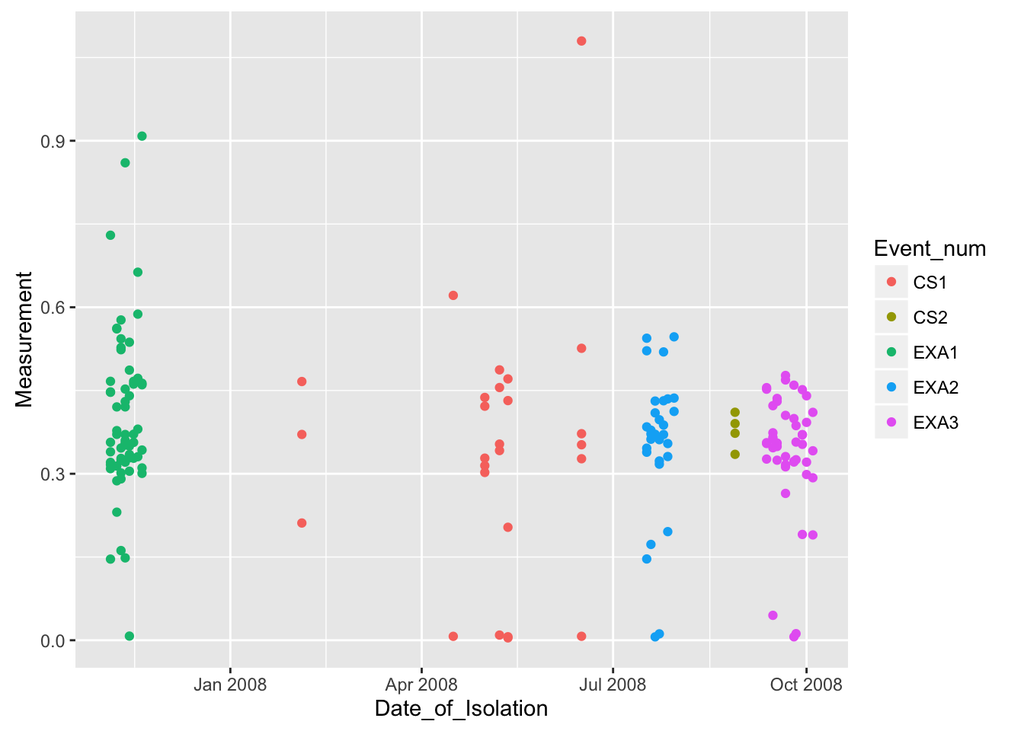

```r
lb_plot = pa_tidy %>% filter(Phenotype == "LB") %>%
    ggplot(aes(x = Date_of_Isolation, y = Measurement)) +
    geom_point(aes(colour = Event_num))
lb_plot
```

We can add a trend line to see if there is a decrease.

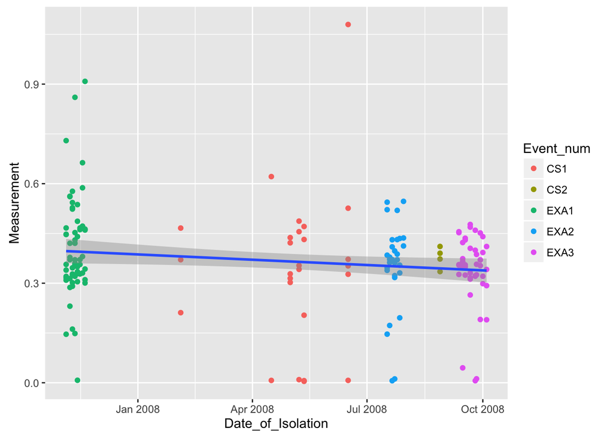

```r
lb_plot + geom_smooth(method = "lm")
```

To get a closer look at each clinical event we can use facets

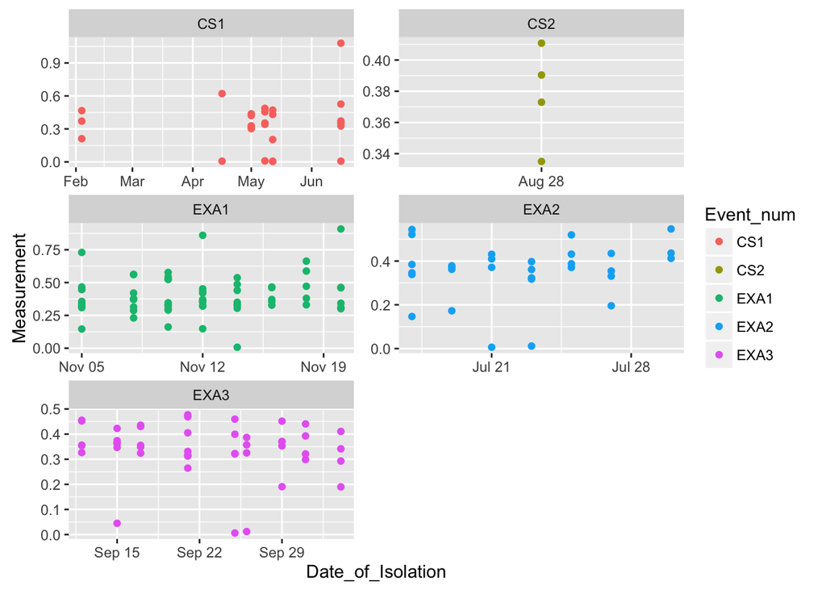

```r
lb_plot + facet_wrap(~Event_num, scales = "free", ncol = 2)
```

Now add the trend line

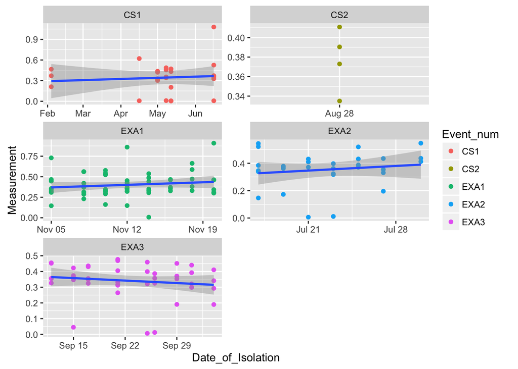

```r
lb_plot + facet_wrap(~Event_num, scales = "free", ncol = 2) + geom_smooth(method = "lm")
```

An alternative view would be to look at the clincal events as boxplots

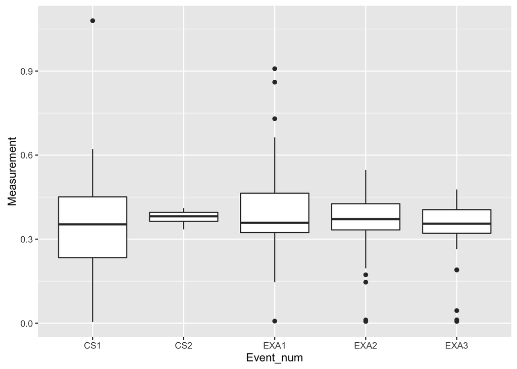

```r
pa_tidy %>% filter(Phenotype == "LB") %>%
    ggplot(aes(x = Event_num, y = Measurement)) +
    geom_boxplot()
```

We can add a colour variable to help view the plot.

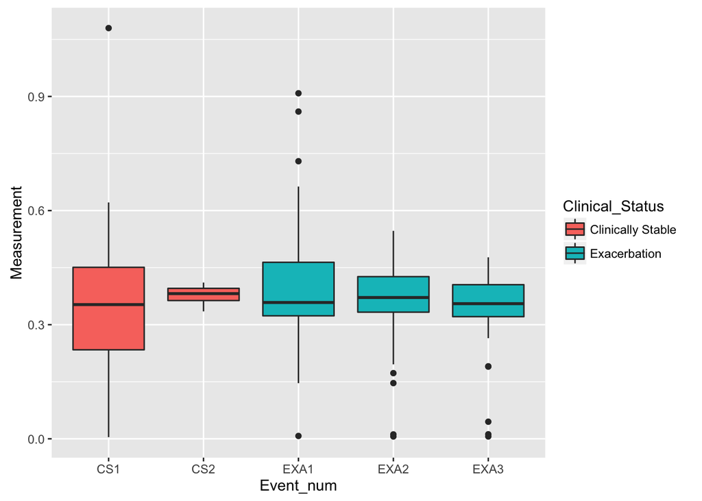

```r
pa_tidy %>% filter(Phenotype == "LB") %>%
    ggplot(aes(x = Event_num, y = Measurement)) +
    geom_boxplot(aes(fill = Clinical_Status))
```